# Utilizing Machine Learning and Keras to Identify Fake News

Machine Learning

HW

Author

Narayanan Kannan

Published

March 25, 2024

# Introduction

Today, we’re going to sift through loads of news data in an attempt to create a model that can accurately identify “fake news” from a host of articles. To do this, we’re going to use keras and tensorflow to create models for text classification. We’ll use most of the following imports below:

```python
!pip install keras --upgrade
```

[output not shown]

```python
import os
os.environ["KERAS_BACKEND"] = "tensorflow"
import re
import string
import keras
from keras import utils
from keras import layers, losses
from keras.layers import TextVectorization
import tensorflow as tf
import tensorflow_datasets as tfds
import numpy as np
import pandas as pd
import matplotlib.pyplot as plt
```

# Dataset Prep

We’re going to take data from the below url, and create a function that creates a dataset from a dataframe made from the csv.

```python
train_url = "https://github.com/PhilChodrow/PIC16b/blob/master/datasets/fake_news_train.csv?raw=true"
df = pd.read_csv(train_url)
```

```python
df
```

|  | Unnamed: 0 | title | text | fake |
| --- | --- | --- | --- | --- |
| 0 | 17366 | Merkel: Strong result for Austria's FPO 'big c... | German Chancellor Angela Merkel said on Monday... | 0 |
| 1 | 5634 | Trump says Pence will lead voter fraud panel | WEST PALM BEACH, Fla.President Donald Trump sa... | 0 |
| 2 | 17487 | JUST IN: SUSPECTED LEAKER and “Close Confidant... | On December 5, 2017, Circa s Sara Carter warne... | 1 |
| 3 | 12217 | Thyssenkrupp has offered help to Argentina ove... | Germany s Thyssenkrupp, has offered assistance... | 0 |
| 4 | 5535 | Trump say appeals court decision on travel ban... | President Donald Trump on Thursday called the ... | 0 |
| ... | ... | ... | ... | ... |
| 22444 | 10709 | ALARMING: NSA Refuses to Release Clinton-Lynch... | If Clinton and Lynch just talked about grandki... | 1 |
| 22445 | 8731 | Can Pence's vow not to sling mud survive a Tru... | () - In 1990, during a close and bitter congre... | 0 |
| 22446 | 4733 | Watch Trump Campaign Try To Spin Their Way Ou... | A new ad by the Hillary Clinton SuperPac Prior... | 1 |
| 22447 | 3993 | Trump celebrates first 100 days as president, ... | HARRISBURG, Pa.U.S. President Donald Trump hit... | 0 |
| 22448 | 12896 | TRUMP SUPPORTERS REACT TO DEBATE: “Clinton New... | MELBOURNE, FL is a town with a population of 7... | 1 |

22449 rows × 4 columns

The two things we want to do before creating the dataset are converting all letters in the dataframe columns “text” and “title” to lowercase and removing stopwords, such as “the,” “at,” and more. To remove stopwords, we need a database of stopwords to watch out for, which is found when importing the nltk library and downloading stopwords.

```python
import nltk
from nltk.corpus import stopwords
nltk.download('stopwords')
```

```
True
```

```python
stop = stopwords.words('english')
```

Our function starts by converting the aforementioned text to lowercase using the .lower() function (after .str() to make sure our values are strings). To remove the stopwords, we use the below lambda function in the .apply() function which only keeps words that aren’t in stop, our list of bad words. Finally, we create a tensorflow dataset out of a tuple of dictionaries named based off the column names in our dataframe. For ease of use, we implement the .batch(100) function so that our dataset unloads data 100 elements at a time, allowing for a streamlined training process with negligible accuracy costs.

```python
def make_dataset(df):
  df['title'] = df['title'].str.lower()
  df['text'] = df['text'].str.lower()
  df['title'] = df['title'].apply(lambda x: ' '.join([word for word in x.split() if word not in stop]))
  df['text'] = df['text'].apply(lambda x: ' '.join([word for word in x.split() if word not in stop]))
  dataset = tf.data.Dataset.from_tensor_slices((
      {'title' : df['title'], 'text' : df['text']}, {'fake' : df['fake']}
  ))
  dataset = dataset.shuffle(buffer_size = len(df), reshuffle_each_iteration=False)
  dataset = dataset.batch(100)
  return dataset
```

We make a dataset, and want to split it into training and validation. A good split would be 80% train, 20% validation. This process is done below.

```python
dataset = make_dataset(df)
```

```python
train_val_split = int(0.2*len(dataset))
train_ds = dataset.skip(train_val_split)
val_ds = dataset.take(train_val_split)
```

As you may recall, a baseline machine learning model in theory just guesses the majority class in the set. We can calculate the base_rate by counting the number of fake news citings in the training set, and dividing it by the total number of elements in the training set. It turns out fake news citings are the majority (barely). Thus, our base rate is approximately 52%.

```python
num_fake = 0

for _, label in train_ds:
    num_fake += np.sum(label['fake'])

base_rate = num_fake/(len(train_ds)*100) # number of fakes over total number of elements in the training set

base_rate
```

```
0.5201666666666667
```

The next thing to do is prepare a vectorization layer that can be implemented into our models. This is made up of a standardization step, and multiple parameters outlining the total number of words to deal with, the output type, and sequence length. Below, we create a vectorization layer for the “title” aspect of each entry in our dataset. If we wanted to, we could create a vectorization layer for the “title” as well (which is shown in the comments below, it’s pretty much the same thing), but this would be redundant, as we would be vectorizing the same piece of data multiple times over, then embedding it twice as well.

```python
#preparing a text vectorization layer for tf model
size_vocabulary = 2000

def standardization(input_data):
    lowercase = tf.strings.lower(input_data)
    no_punctuation = tf.strings.regex_replace(lowercase,
                                  '[%s]' % re.escape(string.punctuation),'')
    return no_punctuation

title_vectorize_layer = TextVectorization(
    standardize=standardization,
    max_tokens=size_vocabulary, # only consider this many words
    output_mode='int',
    output_sequence_length=500)

# text_vectorize_layer = TextVectorization(
    # standardize=standardization,
    # max_tokens=size_vocabulary,
    # output_mode='int',
    # output_sequence_length=500)

title_vectorize_layer.adapt(train_ds.map(lambda x, y: x['title']))
# text_vectorize_layer.adapt(train_ds.map(lambda x, y: x['text']))
```

Next, we have to outline the inputs to our function. On one hand, we have the “title” input, everything seen in the title column of our dataset. On the other hand, we have the “text” input. Since they are both long strings, the semantics are the same.

```python
# inputs
title_input = keras.Input(
    shape = (1,),
    name = "title",
    dtype = "string"
)

text_input = keras.Input(
    shape = (1,),
    name = "text",
    dtype = "string"
)
```

# Model Creation – Our First, “Title”-based, Model

Today, we want to answer the question “*When detecting fake news, is it most effective to focus on only the title of the article, the full text of the article, or both?*” We’ll do this by creating three models. Our first model is only going to process features found in the “title” category of our input data. We use the pipeline seen below. The most important parts are the vectorization layer and the embedding layer, as these help us the most by clarifying what is what in the data. We end with an output layer that classifys what each training sample is.

```python
# layers for processing the title
title_features = title_vectorize_layer(title_input)
title_features = layers.Embedding(size_vocabulary, 3, name = "embedding_title")(title_features)
title_features = layers.Dropout(0.2)(title_features)
title_features = layers.GlobalAveragePooling1D()(title_features)
title_features = layers.Dropout(0.2)(title_features)
title_output = layers.Dense(2, name='fake')(title_features)
```

Instead of using the keras.Sequential API, we use the keras.Functional API to create these models. These consists of inputs which are passed through our features to an output. The hyperparameters and elements such as the optimizer and loss function as the same as always and held constant through our whole experimentation process.

```python
model1 = keras.Model(
    inputs = title_input,
    outputs = title_output
)
model1.compile(optimizer='adam',
              loss=losses.SparseCategoricalCrossentropy(from_logits=True),
              metrics=['accuracy'])
model1.summary()
```

```
Model: "functional_1"
```

```
┏━━━━━━━━━━━━━━━━━━━━━━━━━━━━━━━━━━━━━━┳━━━━━━━━━━━━━━━━━━━━━━━━━━━━━┳━━━━━━━━━━━━━━━━━┓
┃ Layer (type)                         ┃ Output Shape                ┃         Param # ┃
┡━━━━━━━━━━━━━━━━━━━━━━━━━━━━━━━━━━━━━━╇━━━━━━━━━━━━━━━━━━━━━━━━━━━━━╇━━━━━━━━━━━━━━━━━┩
│ title (InputLayer)                   │ (None, 1)                   │               0 │
├──────────────────────────────────────┼─────────────────────────────┼─────────────────┤
│ text_vectorization                   │ (None, 500)                 │               0 │
│ (TextVectorization)                  │                             │                 │
├──────────────────────────────────────┼─────────────────────────────┼─────────────────┤
│ embedding_title (Embedding)          │ (None, 500, 3)              │           6,000 │
├──────────────────────────────────────┼─────────────────────────────┼─────────────────┤
│ dropout (Dropout)                    │ (None, 500, 3)              │               0 │
├──────────────────────────────────────┼─────────────────────────────┼─────────────────┤
│ global_average_pooling1d             │ (None, 3)                   │               0 │
│ (GlobalAveragePooling1D)             │                             │                 │
├──────────────────────────────────────┼─────────────────────────────┼─────────────────┤
│ dropout_1 (Dropout)                  │ (None, 3)                   │               0 │
├──────────────────────────────────────┼─────────────────────────────┼─────────────────┤
│ fake (Dense)                         │ (None, 2)                   │               8 │
└──────────────────────────────────────┴─────────────────────────────┴─────────────────┘
```

```
 Total params: 6,008 (23.47 KB)
```

```
 Trainable params: 6,008 (23.47 KB)
```

```
 Non-trainable params: 0 (0.00 B)
```

As you can see, when just processing the title, we achieve an accuracy of around 90% at peak performance. This is pretty good! But I think we can do better.

```python
callback = keras.callbacks.EarlyStopping(monitor='val_loss', patience=5)
history = model1.fit(train_ds,
                    validation_data=val_ds,
                    epochs = 50,
                    callbacks=[callback],
                    verbose = True)
```

```
180/180 ━━━━━━━━━━━━━━━━━━━━ 8s 6ms/step - accuracy: 0.5148 - loss: 0.6929 - val_accuracy: 0.5282 - val_loss: 0.6905
180/180 ━━━━━━━━━━━━━━━━━━━━ 5s 6ms/step - accuracy: 0.5220 - loss: 0.6910 - val_accuracy: 0.5282 - val_loss: 0.6889
180/180 ━━━━━━━━━━━━━━━━━━━━ 1s 6ms/step - accuracy: 0.5316 - loss: 0.6895 - val_accuracy: 0.5282 - val_loss: 0.6861
180/180 ━━━━━━━━━━━━━━━━━━━━ 1s 6ms/step - accuracy: 0.5487 - loss: 0.6877 - val_accuracy: 0.5282 - val_loss: 0.6824
180/180 ━━━━━━━━━━━━━━━━━━━━ 1s 5ms/step - accuracy: 0.5583 - loss: 0.6841 - val_accuracy: 0.5282 - val_loss: 0.6772
180/180 ━━━━━━━━━━━━━━━━━━━━ 2s 9ms/step - accuracy: 0.5815 - loss: 0.6782 - val_accuracy: 0.5282 - val_loss: 0.6687
180/180 ━━━━━━━━━━━━━━━━━━━━ 1s 8ms/step - accuracy: 0.5967 - loss: 0.6699 - val_accuracy: 0.5282 - val_loss: 0.6635
180/180 ━━━━━━━━━━━━━━━━━━━━ 2s 5ms/step - accuracy: 0.6070 - loss: 0.6605 - val_accuracy: 0.5282 - val_loss: 0.6575
180/180 ━━━━━━━━━━━━━━━━━━━━ 1s 6ms/step - accuracy: 0.6202 - loss: 0.6502 - val_accuracy: 0.5420 - val_loss: 0.6382
180/180 ━━━━━━━━━━━━━━━━━━━━ 1s 6ms/step - accuracy: 0.6631 - loss: 0.6345 - val_accuracy: 0.6196 - val_loss: 0.6194
180/180 ━━━━━━━━━━━━━━━━━━━━ 1s 6ms/step - accuracy: 0.6906 - loss: 0.6191 - val_accuracy: 0.6707 - val_loss: 0.6026
180/180 ━━━━━━━━━━━━━━━━━━━━ 1s 6ms/step - accuracy: 0.7079 - loss: 0.6057 - val_accuracy: 0.7691 - val_loss: 0.5797
180/180 ━━━━━━━━━━━━━━━━━━━━ 1s 5ms/step - accuracy: 0.7259 - loss: 0.5890 - val_accuracy: 0.7716 - val_loss: 0.5645
180/180 ━━━━━━━━━━━━━━━━━━━━ 1s 5ms/step - accuracy: 0.7430 - loss: 0.5722 - val_accuracy: 0.7962 - val_loss: 0.5486
180/180 ━━━━━━━━━━━━━━━━━━━━ 1s 6ms/step - accuracy: 0.7445 - loss: 0.5623 - val_accuracy: 0.8038 - val_loss: 0.5346
180/180 ━━━━━━━━━━━━━━━━━━━━ 2s 9ms/step - accuracy: 0.7587 - loss: 0.5472 - val_accuracy: 0.7969 - val_loss: 0.5228
180/180 ━━━━━━━━━━━━━━━━━━━━ 2s 5ms/step - accuracy: 0.7630 - loss: 0.5363 - val_accuracy: 0.8116 - val_loss: 0.5089
180/180 ━━━━━━━━━━━━━━━━━━━━ 1s 5ms/step - accuracy: 0.7568 - loss: 0.5267 - val_accuracy: 0.7998 - val_loss: 0.4991
180/180 ━━━━━━━━━━━━━━━━━━━━ 1s 5ms/step - accuracy: 0.7716 - loss: 0.5163 - val_accuracy: 0.8187 - val_loss: 0.4861
180/180 ━━━━━━━━━━━━━━━━━━━━ 1s 6ms/step - accuracy: 0.7785 - loss: 0.5055 - val_accuracy: 0.8204 - val_loss: 0.4751
180/180 ━━━━━━━━━━━━━━━━━━━━ 1s 5ms/step - accuracy: 0.7885 - loss: 0.4940 - val_accuracy: 0.8144 - val_loss: 0.4668
180/180 ━━━━━━━━━━━━━━━━━━━━ 1s 6ms/step - accuracy: 0.7892 - loss: 0.4869 - val_accuracy: 0.8200 - val_loss: 0.4564
180/180 ━━━━━━━━━━━━━━━━━━━━ 1s 6ms/step - accuracy: 0.7853 - loss: 0.4789 - val_accuracy: 0.8262 - val_loss: 0.4465
180/180 ━━━━━━━━━━━━━━━━━━━━ 1s 5ms/step - accuracy: 0.7944 - loss: 0.4714 - val_accuracy: 0.8240 - val_loss: 0.4401
180/180 ━━━━━━━━━━━━━━━━━━━━ 2s 8ms/step - accuracy: 0.8041 - loss: 0.4602 - val_accuracy: 0.8269 - val_loss: 0.4310
180/180 ━━━━━━━━━━━━━━━━━━━━ 2s 9ms/step - accuracy: 0.8077 - loss: 0.4520 - val_accuracy: 0.8316 - val_loss: 0.4222
180/180 ━━━━━━━━━━━━━━━━━━━━ 2s 8ms/step - accuracy: 0.8109 - loss: 0.4439 - val_accuracy: 0.8378 - val_loss: 0.4131
180/180 ━━━━━━━━━━━━━━━━━━━━ 2s 6ms/step - accuracy: 0.8152 - loss: 0.4372 - val_accuracy: 0.8369 - val_loss: 0.4087
180/180 ━━━━━━━━━━━━━━━━━━━━ 1s 5ms/step - accuracy: 0.8218 - loss: 0.4241 - val_accuracy: 0.8431 - val_loss: 0.3984
180/180 ━━━━━━━━━━━━━━━━━━━━ 1s 6ms/step - accuracy: 0.8214 - loss: 0.4219 - val_accuracy: 0.8402 - val_loss: 0.3955
180/180 ━━━━━━━━━━━━━━━━━━━━ 1s 5ms/step - accuracy: 0.8269 - loss: 0.4113 - val_accuracy: 0.8371 - val_loss: 0.3931
180/180 ━━━━━━━━━━━━━━━━━━━━ 1s 5ms/step - accuracy: 0.8321 - loss: 0.4071 - val_accuracy: 0.8491 - val_loss: 0.3801
180/180 ━━━━━━━━━━━━━━━━━━━━ 1s 6ms/step - accuracy: 0.8323 - loss: 0.4000 - val_accuracy: 0.8484 - val_loss: 0.3745
180/180 ━━━━━━━━━━━━━━━━━━━━ 2s 9ms/step - accuracy: 0.8382 - loss: 0.3931 - val_accuracy: 0.8609 - val_loss: 0.3596
180/180 ━━━━━━━━━━━━━━━━━━━━ 2s 6ms/step - accuracy: 0.8393 - loss: 0.3866 - val_accuracy: 0.8602 - val_loss: 0.3544
180/180 ━━━━━━━━━━━━━━━━━━━━ 1s 5ms/step - accuracy: 0.8501 - loss: 0.3743 - val_accuracy: 0.8662 - val_loss: 0.3457
180/180 ━━━━━━━━━━━━━━━━━━━━ 1s 6ms/step - accuracy: 0.8527 - loss: 0.3680 - val_accuracy: 0.8722 - val_loss: 0.3373
180/180 ━━━━━━━━━━━━━━━━━━━━ 1s 6ms/step - accuracy: 0.8501 - loss: 0.3659 - val_accuracy: 0.8676 - val_loss: 0.3361
180/180 ━━━━━━━━━━━━━━━━━━━━ 1s 5ms/step - accuracy: 0.8585 - loss: 0.3568 - val_accuracy: 0.8742 - val_loss: 0.3264
180/180 ━━━━━━━━━━━━━━━━━━━━ 1s 6ms/step - accuracy: 0.8576 - loss: 0.3537 - val_accuracy: 0.8836 - val_loss: 0.3181
180/180 ━━━━━━━━━━━━━━━━━━━━ 1s 5ms/step - accuracy: 0.8621 - loss: 0.3497 - val_accuracy: 0.8809 - val_loss: 0.3144
180/180 ━━━━━━━━━━━━━━━━━━━━ 1s 5ms/step - accuracy: 0.8644 - loss: 0.3419 - val_accuracy: 0.8887 - val_loss: 0.3062
180/180 ━━━━━━━━━━━━━━━━━━━━ 1s 8ms/step - accuracy: 0.8647 - loss: 0.3381 - val_accuracy: 0.8829 - val_loss: 0.3043
180/180 ━━━━━━━━━━━━━━━━━━━━ 2s 9ms/step - accuracy: 0.8728 - loss: 0.3326 - val_accuracy: 0.8913 - val_loss: 0.2953
180/180 ━━━━━━━━━━━━━━━━━━━━ 2s 6ms/step - accuracy: 0.8707 - loss: 0.3291 - val_accuracy: 0.8911 - val_loss: 0.2911
180/180 ━━━━━━━━━━━━━━━━━━━━ 1s 5ms/step - accuracy: 0.8784 - loss: 0.3189 - val_accuracy: 0.8933 - val_loss: 0.2857
180/180 ━━━━━━━━━━━━━━━━━━━━ 1s 5ms/step - accuracy: 0.8740 - loss: 0.3193 - val_accuracy: 0.8902 - val_loss: 0.2870
180/180 ━━━━━━━━━━━━━━━━━━━━ 1s 5ms/step - accuracy: 0.8790 - loss: 0.3129 - val_accuracy: 0.8980 - val_loss: 0.2792
180/180 ━━━━━━━━━━━━━━━━━━━━ 1s 6ms/step - accuracy: 0.8791 - loss: 0.3126 - val_accuracy: 0.9004 - val_loss: 0.2718
180/180 ━━━━━━━━━━━━━━━━━━━━ 1s 5ms/step - accuracy: 0.8813 - loss: 0.3068 - val_accuracy: 0.9042 - val_loss: 0.2670
```

```python
plt.plot(history.history["accuracy"], label = "training")
plt.plot(history.history["val_accuracy"], label = "validation")
plt.gca().set(xlabel = "epoch", ylabel = "accuracy")
plt.legend()
plt.title("Visualizing Our First Model")
```

[figure not shown]

Before we jump into the next model, here’s a streamlined look at the current one. It’s really not that complex, but it more than gets the job done.

```python
from keras import utils
utils.plot_model(model1, "model1.png",
                       show_shapes=True,
                       show_layer_names=True)
```

[figure not shown]

# A Model That Only Looks at Text Data

Now we’ll tackle the second idea posed in the question – how good is a model that only processes the text of an article. I hypothesize that this will be a little bit better than just looking at the title. The body of the article is a lot longer, and gives us a better idea of what’s going on. We use the same model structure for this model, only changing the input and embedding layer.

```python
# layers for processing the text
text_features = title_vectorize_layer(text_input)
text_features = layers.Embedding(size_vocabulary, 3, name = "embedding_text")(text_features)
text_features = layers.Dropout(0.2)(text_features)
text_features = layers.GlobalAveragePooling1D()(text_features)
text_features = layers.Dropout(0.2)(text_features)
text_output = layers.Dense(2, name='fake')(text_features)
```

```python
model2 = keras.Model(
    inputs = text_input,
    outputs = text_output
)
model2.compile(optimizer='adam',
              loss=losses.SparseCategoricalCrossentropy(from_logits=True),
              metrics=['accuracy'])
model2.summary()
```

```
Model: "functional_3"
```

```
┏━━━━━━━━━━━━━━━━━━━━━━━━━━━━━━━━━━━━━━┳━━━━━━━━━━━━━━━━━━━━━━━━━━━━━┳━━━━━━━━━━━━━━━━━┓
┃ Layer (type)                         ┃ Output Shape                ┃         Param # ┃
┡━━━━━━━━━━━━━━━━━━━━━━━━━━━━━━━━━━━━━━╇━━━━━━━━━━━━━━━━━━━━━━━━━━━━━╇━━━━━━━━━━━━━━━━━┩
│ text (InputLayer)                    │ (None, 1)                   │               0 │
├──────────────────────────────────────┼─────────────────────────────┼─────────────────┤
│ text_vectorization                   │ (None, 500)                 │               0 │
│ (TextVectorization)                  │                             │                 │
├──────────────────────────────────────┼─────────────────────────────┼─────────────────┤
│ embedding_text (Embedding)           │ (None, 500, 3)              │           6,000 │
├──────────────────────────────────────┼─────────────────────────────┼─────────────────┤
│ dropout_2 (Dropout)                  │ (None, 500, 3)              │               0 │
├──────────────────────────────────────┼─────────────────────────────┼─────────────────┤
│ global_average_pooling1d_1           │ (None, 3)                   │               0 │
│ (GlobalAveragePooling1D)             │                             │                 │
├──────────────────────────────────────┼─────────────────────────────┼─────────────────┤
│ dropout_3 (Dropout)                  │ (None, 3)                   │               0 │
├──────────────────────────────────────┼─────────────────────────────┼─────────────────┤
│ fake (Dense)                         │ (None, 2)                   │               8 │
└──────────────────────────────────────┴─────────────────────────────┴─────────────────┘
```

```
 Total params: 6,008 (23.47 KB)
```

```
 Trainable params: 6,008 (23.47 KB)
```

```
 Non-trainable params: 0 (0.00 B)
```

At its peak, this model reaches almost 97% accuracy, which is sizably better than our original one. So my hypothesis was correct! Still, I think we can do *even* better.

```python
callback = keras.callbacks.EarlyStopping(monitor='val_loss', patience=5)
history = model2.fit(train_ds,
                    validation_data=val_ds,
                    epochs = 50,
                    callbacks=[callback],
                    verbose = True)
```

```
180/180 ━━━━━━━━━━━━━━━━━━━━ 3s 12ms/step - accuracy: 0.5280 - loss: 0.6868 - val_accuracy: 0.5900 - val_loss: 0.6565
180/180 ━━━━━━━━━━━━━━━━━━━━ 3s 12ms/step - accuracy: 0.6833 - loss: 0.6433 - val_accuracy: 0.7289 - val_loss: 0.5874
180/180 ━━━━━━━━━━━━━━━━━━━━ 3s 15ms/step - accuracy: 0.8256 - loss: 0.5701 - val_accuracy: 0.8136 - val_loss: 0.5067
180/180 ━━━━━━━━━━━━━━━━━━━━ 4s 11ms/step - accuracy: 0.8772 - loss: 0.4941 - val_accuracy: 0.8609 - val_loss: 0.4368
180/180 ━━━━━━━━━━━━━━━━━━━━ 3s 11ms/step - accuracy: 0.9001 - loss: 0.4291 - val_accuracy: 0.8880 - val_loss: 0.3819
180/180 ━━━━━━━━━━━━━━━━━━━━ 2s 11ms/step - accuracy: 0.9118 - loss: 0.3814 - val_accuracy: 0.9038 - val_loss: 0.3411
180/180 ━━━━━━━━━━━━━━━━━━━━ 4s 16ms/step - accuracy: 0.9181 - loss: 0.3429 - val_accuracy: 0.9133 - val_loss: 0.3096
180/180 ━━━━━━━━━━━━━━━━━━━━ 4s 11ms/step - accuracy: 0.9242 - loss: 0.3135 - val_accuracy: 0.9127 - val_loss: 0.2864
180/180 ━━━━━━━━━━━━━━━━━━━━ 2s 10ms/step - accuracy: 0.9269 - loss: 0.2932 - val_accuracy: 0.9158 - val_loss: 0.2678
180/180 ━━━━━━━━━━━━━━━━━━━━ 3s 11ms/step - accuracy: 0.9315 - loss: 0.2712 - val_accuracy: 0.9311 - val_loss: 0.2481
180/180 ━━━━━━━━━━━━━━━━━━━━ 3s 14ms/step - accuracy: 0.9294 - loss: 0.2596 - val_accuracy: 0.9300 - val_loss: 0.2366
180/180 ━━━━━━━━━━━━━━━━━━━━ 4s 11ms/step - accuracy: 0.9356 - loss: 0.2420 - val_accuracy: 0.9333 - val_loss: 0.2252
180/180 ━━━━━━━━━━━━━━━━━━━━ 2s 11ms/step - accuracy: 0.9348 - loss: 0.2341 - val_accuracy: 0.9362 - val_loss: 0.2143
180/180 ━━━━━━━━━━━━━━━━━━━━ 3s 11ms/step - accuracy: 0.9378 - loss: 0.2246 - val_accuracy: 0.9376 - val_loss: 0.2068
180/180 ━━━━━━━━━━━━━━━━━━━━ 2s 11ms/step - accuracy: 0.9392 - loss: 0.2166 - val_accuracy: 0.9398 - val_loss: 0.1988
180/180 ━━━━━━━━━━━━━━━━━━━━ 3s 16ms/step - accuracy: 0.9428 - loss: 0.2079 - val_accuracy: 0.9442 - val_loss: 0.1913
180/180 ━━━━━━━━━━━━━━━━━━━━ 4s 11ms/step - accuracy: 0.9427 - loss: 0.2008 - val_accuracy: 0.9420 - val_loss: 0.1876
180/180 ━━━━━━━━━━━━━━━━━━━━ 3s 11ms/step - accuracy: 0.9459 - loss: 0.1959 - val_accuracy: 0.9464 - val_loss: 0.1808
180/180 ━━━━━━━━━━━━━━━━━━━━ 3s 14ms/step - accuracy: 0.9459 - loss: 0.1900 - val_accuracy: 0.9480 - val_loss: 0.1758
180/180 ━━━━━━━━━━━━━━━━━━━━ 4s 25ms/step - accuracy: 0.9502 - loss: 0.1859 - val_accuracy: 0.9482 - val_loss: 0.1716
180/180 ━━━━━━━━━━━━━━━━━━━━ 3s 11ms/step - accuracy: 0.9503 - loss: 0.1838 - val_accuracy: 0.9482 - val_loss: 0.1691
180/180 ━━━━━━━━━━━━━━━━━━━━ 2s 11ms/step - accuracy: 0.9489 - loss: 0.1765 - val_accuracy: 0.9482 - val_loss: 0.1665
180/180 ━━━━━━━━━━━━━━━━━━━━ 2s 11ms/step - accuracy: 0.9504 - loss: 0.1747 - val_accuracy: 0.9491 - val_loss: 0.1630
180/180 ━━━━━━━━━━━━━━━━━━━━ 2s 11ms/step - accuracy: 0.9517 - loss: 0.1705 - val_accuracy: 0.9509 - val_loss: 0.1588
180/180 ━━━━━━━━━━━━━━━━━━━━ 4s 17ms/step - accuracy: 0.9544 - loss: 0.1646 - val_accuracy: 0.9516 - val_loss: 0.1556
180/180 ━━━━━━━━━━━━━━━━━━━━ 4s 12ms/step - accuracy: 0.9551 - loss: 0.1613 - val_accuracy: 0.9531 - val_loss: 0.1525
180/180 ━━━━━━━━━━━━━━━━━━━━ 2s 11ms/step - accuracy: 0.9547 - loss: 0.1613 - val_accuracy: 0.9509 - val_loss: 0.1515
180/180 ━━━━━━━━━━━━━━━━━━━━ 2s 11ms/step - accuracy: 0.9562 - loss: 0.1585 - val_accuracy: 0.9553 - val_loss: 0.1474
180/180 ━━━━━━━━━━━━━━━━━━━━ 2s 14ms/step - accuracy: 0.9535 - loss: 0.1540 - val_accuracy: 0.9549 - val_loss: 0.1450
180/180 ━━━━━━━━━━━━━━━━━━━━ 3s 14ms/step - accuracy: 0.9564 - loss: 0.1532 - val_accuracy: 0.9571 - val_loss: 0.1423
180/180 ━━━━━━━━━━━━━━━━━━━━ 4s 10ms/step - accuracy: 0.9551 - loss: 0.1480 - val_accuracy: 0.9558 - val_loss: 0.1415
180/180 ━━━━━━━━━━━━━━━━━━━━ 2s 11ms/step - accuracy: 0.9596 - loss: 0.1466 - val_accuracy: 0.9538 - val_loss: 0.1414
180/180 ━━━━━━━━━━━━━━━━━━━━ 3s 11ms/step - accuracy: 0.9591 - loss: 0.1454 - val_accuracy: 0.9598 - val_loss: 0.1364
180/180 ━━━━━━━━━━━━━━━━━━━━ 3s 16ms/step - accuracy: 0.9555 - loss: 0.1433 - val_accuracy: 0.9538 - val_loss: 0.1403
180/180 ━━━━━━━━━━━━━━━━━━━━ 4s 11ms/step - accuracy: 0.9580 - loss: 0.1426 - val_accuracy: 0.9600 - val_loss: 0.1341
180/180 ━━━━━━━━━━━━━━━━━━━━ 3s 10ms/step - accuracy: 0.9610 - loss: 0.1410 - val_accuracy: 0.9560 - val_loss: 0.1355
180/180 ━━━━━━━━━━━━━━━━━━━━ 3s 10ms/step - accuracy: 0.9600 - loss: 0.1398 - val_accuracy: 0.9593 - val_loss: 0.1320
180/180 ━━━━━━━━━━━━━━━━━━━━ 3s 15ms/step - accuracy: 0.9614 - loss: 0.1333 - val_accuracy: 0.9598 - val_loss: 0.1308
180/180 ━━━━━━━━━━━━━━━━━━━━ 4s 10ms/step - accuracy: 0.9633 - loss: 0.1319 - val_accuracy: 0.9582 - val_loss: 0.1313
180/180 ━━━━━━━━━━━━━━━━━━━━ 2s 11ms/step - accuracy: 0.9625 - loss: 0.1342 - val_accuracy: 0.9587 - val_loss: 0.1300
180/180 ━━━━━━━━━━━━━━━━━━━━ 2s 12ms/step - accuracy: 0.9626 - loss: 0.1344 - val_accuracy: 0.9584 - val_loss: 0.1287
180/180 ━━━━━━━━━━━━━━━━━━━━ 2s 11ms/step - accuracy: 0.9620 - loss: 0.1308 - val_accuracy: 0.9576 - val_loss: 0.1318
180/180 ━━━━━━━━━━━━━━━━━━━━ 3s 16ms/step - accuracy: 0.9612 - loss: 0.1307 - val_accuracy: 0.9596 - val_loss: 0.1273
180/180 ━━━━━━━━━━━━━━━━━━━━ 4s 11ms/step - accuracy: 0.9636 - loss: 0.1223 - val_accuracy: 0.9620 - val_loss: 0.1240
180/180 ━━━━━━━━━━━━━━━━━━━━ 2s 11ms/step - accuracy: 0.9638 - loss: 0.1251 - val_accuracy: 0.9609 - val_loss: 0.1248
180/180 ━━━━━━━━━━━━━━━━━━━━ 2s 11ms/step - accuracy: 0.9624 - loss: 0.1272 - val_accuracy: 0.9622 - val_loss: 0.1232
180/180 ━━━━━━━━━━━━━━━━━━━━ 3s 13ms/step - accuracy: 0.9636 - loss: 0.1210 - val_accuracy: 0.9629 - val_loss: 0.1215
180/180 ━━━━━━━━━━━━━━━━━━━━ 3s 14ms/step - accuracy: 0.9668 - loss: 0.1177 - val_accuracy: 0.9600 - val_loss: 0.1244
180/180 ━━━━━━━━━━━━━━━━━━━━ 2s 11ms/step - accuracy: 0.9655 - loss: 0.1197 - val_accuracy: 0.9620 - val_loss: 0.1212
180/180 ━━━━━━━━━━━━━━━━━━━━ 3s 11ms/step - accuracy: 0.9646 - loss: 0.1198 - val_accuracy: 0.9636 - val_loss: 0.1195
```

```python
plt.plot(history.history["accuracy"], label = "training")
plt.plot(history.history["val_accuracy"], label = "validation")
plt.gca().set(xlabel = "epoch", ylabel = "accuracy")
plt.legend()
plt.title("Visualizing Our Second Model")
```

[figure not shown]

As I said before, the backbone of this model is the same as the model processing the titles.

```python
from keras import utils
utils.plot_model(model2, "model2.png",
                       show_shapes=True,
                       show_layer_names=True)
```

[figure not shown]

# An All-Encompassing Model

Our final model should be the best. It takes into account both the title data and text data, and should provide us with the fullest picture of what’s happening in each article. In this model, we concatenate the features of both other models in order to process the title and text data in tandem before finally feeding to a dense layer for classification.

```python
# processing both the title and text together
main = layers.concatenate([title_features, text_features], axis = 1)
output = layers.Dense(2, name = 'fake')(main)
```

```python
model3 = keras.Model(
    inputs = [title_input, text_input],
    outputs = output
)
model3.compile(optimizer='adam',
              loss=losses.SparseCategoricalCrossentropy(from_logits=True),
              metrics=['accuracy'])
model3.summary()
```

```
Model: "functional_5"
```

```
┏━━━━━━━━━━━━━━━━━━━━━━━━━━━┳━━━━━━━━━━━━━━━━━━━━━━━━┳━━━━━━━━━━━━━━━━┳━━━━━━━━━━━━━━━━━━━━━━━━┓
┃ Layer (type)              ┃ Output Shape           ┃        Param # ┃ Connected to           ┃
┡━━━━━━━━━━━━━━━━━━━━━━━━━━━╇━━━━━━━━━━━━━━━━━━━━━━━━╇━━━━━━━━━━━━━━━━╇━━━━━━━━━━━━━━━━━━━━━━━━┩
│ title (InputLayer)        │ (None, 1)              │              0 │ -                      │
├───────────────────────────┼────────────────────────┼────────────────┼────────────────────────┤
│ text (InputLayer)         │ (None, 1)              │              0 │ -                      │
├───────────────────────────┼────────────────────────┼────────────────┼────────────────────────┤
│ text_vectorization        │ (None, 500)            │              0 │ title[0][0],           │
│ (TextVectorization)       │                        │                │ text[0][0]             │
├───────────────────────────┼────────────────────────┼────────────────┼────────────────────────┤
│ embedding_title           │ (None, 500, 3)         │          6,000 │ text_vectorization[0]… │
│ (Embedding)               │                        │                │                        │
├───────────────────────────┼────────────────────────┼────────────────┼────────────────────────┤
│ embedding_text            │ (None, 500, 3)         │          6,000 │ text_vectorization[1]… │
│ (Embedding)               │                        │                │                        │
├───────────────────────────┼────────────────────────┼────────────────┼────────────────────────┤
│ dropout (Dropout)         │ (None, 500, 3)         │              0 │ embedding_title[0][0]  │
├───────────────────────────┼────────────────────────┼────────────────┼────────────────────────┤
│ dropout_2 (Dropout)       │ (None, 500, 3)         │              0 │ embedding_text[0][0]   │
├───────────────────────────┼────────────────────────┼────────────────┼────────────────────────┤
│ global_average_pooling1d  │ (None, 3)              │              0 │ dropout[0][0]          │
│ (GlobalAveragePooling1D)  │                        │                │                        │
├───────────────────────────┼────────────────────────┼────────────────┼────────────────────────┤
│ global_average_pooling1d… │ (None, 3)              │              0 │ dropout_2[0][0]        │
│ (GlobalAveragePooling1D)  │                        │                │                        │
├───────────────────────────┼────────────────────────┼────────────────┼────────────────────────┤
│ dropout_1 (Dropout)       │ (None, 3)              │              0 │ global_average_poolin… │
├───────────────────────────┼────────────────────────┼────────────────┼────────────────────────┤
│ dropout_3 (Dropout)       │ (None, 3)              │              0 │ global_average_poolin… │
├───────────────────────────┼────────────────────────┼────────────────┼────────────────────────┤
│ concatenate (Concatenate) │ (None, 6)              │              0 │ dropout_1[0][0],       │
│                           │                        │                │ dropout_3[0][0]        │
├───────────────────────────┼────────────────────────┼────────────────┼────────────────────────┤
│ fake (Dense)              │ (None, 2)              │             14 │ concatenate[0][0]      │
└───────────────────────────┴────────────────────────┴────────────────┴────────────────────────┘
```

```
 Total params: 12,014 (46.93 KB)
```

```
 Trainable params: 12,014 (46.93 KB)
```

```
 Non-trainable params: 0 (0.00 B)
```

This model is consistently above 97%, and eclipses 98% validation accuracy at the end of training. It is truly the culmination of all the work we’ve done so far. It is almost scarily accuracte. It could even be better than you or me!

```python
callback = keras.callbacks.EarlyStopping(monitor='val_loss', patience=5)
history = model3.fit(train_ds,
                    validation_data=val_ds,
                    epochs = 50,
                    callbacks=[callback],
                    verbose = True)
```

```
180/180 ━━━━━━━━━━━━━━━━━━━━ 4s 15ms/step - accuracy: 0.2719 - loss: 0.7735 - val_accuracy: 0.6147 - val_loss: 0.6652
180/180 ━━━━━━━━━━━━━━━━━━━━ 4s 21ms/step - accuracy: 0.7286 - loss: 0.6393 - val_accuracy: 0.8547 - val_loss: 0.5517
180/180 ━━━━━━━━━━━━━━━━━━━━ 7s 35ms/step - accuracy: 0.8925 - loss: 0.5298 - val_accuracy: 0.9271 - val_loss: 0.4559
180/180 ━━━━━━━━━━━━━━━━━━━━ 5s 28ms/step - accuracy: 0.9435 - loss: 0.4410 - val_accuracy: 0.9211 - val_loss: 0.3848
180/180 ━━━━━━━━━━━━━━━━━━━━ 7s 12ms/step - accuracy: 0.9518 - loss: 0.3713 - val_accuracy: 0.9453 - val_loss: 0.3255
180/180 ━━━━━━━━━━━━━━━━━━━━ 3s 12ms/step - accuracy: 0.9563 - loss: 0.3200 - val_accuracy: 0.9553 - val_loss: 0.2800
180/180 ━━━━━━━━━━━━━━━━━━━━ 2s 12ms/step - accuracy: 0.9612 - loss: 0.2768 - val_accuracy: 0.9544 - val_loss: 0.2493
180/180 ━━━━━━━━━━━━━━━━━━━━ 4s 18ms/step - accuracy: 0.9633 - loss: 0.2464 - val_accuracy: 0.9620 - val_loss: 0.2208
180/180 ━━━━━━━━━━━━━━━━━━━━ 2s 13ms/step - accuracy: 0.9636 - loss: 0.2246 - val_accuracy: 0.9671 - val_loss: 0.1983
180/180 ━━━━━━━━━━━━━━━━━━━━ 2s 12ms/step - accuracy: 0.9647 - loss: 0.2054 - val_accuracy: 0.9678 - val_loss: 0.1822
180/180 ━━━━━━━━━━━━━━━━━━━━ 3s 12ms/step - accuracy: 0.9682 - loss: 0.1878 - val_accuracy: 0.9704 - val_loss: 0.1678
180/180 ━━━━━━━━━━━━━━━━━━━━ 2s 12ms/step - accuracy: 0.9663 - loss: 0.1764 - val_accuracy: 0.9707 - val_loss: 0.1567
180/180 ━━━━━━━━━━━━━━━━━━━━ 3s 18ms/step - accuracy: 0.9680 - loss: 0.1653 - val_accuracy: 0.9711 - val_loss: 0.1475
180/180 ━━━━━━━━━━━━━━━━━━━━ 3s 14ms/step - accuracy: 0.9673 - loss: 0.1557 - val_accuracy: 0.9709 - val_loss: 0.1403
180/180 ━━━━━━━━━━━━━━━━━━━━ 5s 12ms/step - accuracy: 0.9672 - loss: 0.1490 - val_accuracy: 0.9720 - val_loss: 0.1329
180/180 ━━━━━━━━━━━━━━━━━━━━ 2s 12ms/step - accuracy: 0.9696 - loss: 0.1411 - val_accuracy: 0.9720 - val_loss: 0.1276
180/180 ━━━━━━━━━━━━━━━━━━━━ 3s 16ms/step - accuracy: 0.9697 - loss: 0.1348 - val_accuracy: 0.9724 - val_loss: 0.1217
180/180 ━━━━━━━━━━━━━━━━━━━━ 4s 12ms/step - accuracy: 0.9688 - loss: 0.1299 - val_accuracy: 0.9718 - val_loss: 0.1181
180/180 ━━━━━━━━━━━━━━━━━━━━ 2s 12ms/step - accuracy: 0.9703 - loss: 0.1232 - val_accuracy: 0.9738 - val_loss: 0.1128
180/180 ━━━━━━━━━━━━━━━━━━━━ 3s 12ms/step - accuracy: 0.9709 - loss: 0.1197 - val_accuracy: 0.9742 - val_loss: 0.1087
180/180 ━━━━━━━━━━━━━━━━━━━━ 3s 15ms/step - accuracy: 0.9709 - loss: 0.1177 - val_accuracy: 0.9751 - val_loss: 0.1045
180/180 ━━━━━━━━━━━━━━━━━━━━ 3s 16ms/step - accuracy: 0.9711 - loss: 0.1119 - val_accuracy: 0.9753 - val_loss: 0.1020
180/180 ━━━━━━━━━━━━━━━━━━━━ 4s 12ms/step - accuracy: 0.9734 - loss: 0.1085 - val_accuracy: 0.9744 - val_loss: 0.1003
180/180 ━━━━━━━━━━━━━━━━━━━━ 2s 12ms/step - accuracy: 0.9719 - loss: 0.1062 - val_accuracy: 0.9764 - val_loss: 0.0940
180/180 ━━━━━━━━━━━━━━━━━━━━ 2s 12ms/step - accuracy: 0.9714 - loss: 0.1041 - val_accuracy: 0.9736 - val_loss: 0.0972
180/180 ━━━━━━━━━━━━━━━━━━━━ 3s 19ms/step - accuracy: 0.9747 - loss: 0.0999 - val_accuracy: 0.9756 - val_loss: 0.0906
180/180 ━━━━━━━━━━━━━━━━━━━━ 4s 12ms/step - accuracy: 0.9722 - loss: 0.1000 - val_accuracy: 0.9738 - val_loss: 0.0933
180/180 ━━━━━━━━━━━━━━━━━━━━ 3s 12ms/step - accuracy: 0.9741 - loss: 0.0964 - val_accuracy: 0.9767 - val_loss: 0.0873
180/180 ━━━━━━━━━━━━━━━━━━━━ 3s 12ms/step - accuracy: 0.9731 - loss: 0.0940 - val_accuracy: 0.9751 - val_loss: 0.0879
180/180 ━━━━━━━━━━━━━━━━━━━━ 4s 19ms/step - accuracy: 0.9738 - loss: 0.0915 - val_accuracy: 0.9767 - val_loss: 0.0834
180/180 ━━━━━━━━━━━━━━━━━━━━ 4s 12ms/step - accuracy: 0.9749 - loss: 0.0900 - val_accuracy: 0.9762 - val_loss: 0.0863
180/180 ━━━━━━━━━━━━━━━━━━━━ 3s 13ms/step - accuracy: 0.9733 - loss: 0.0908 - val_accuracy: 0.9776 - val_loss: 0.0823
180/180 ━━━━━━━━━━━━━━━━━━━━ 2s 12ms/step - accuracy: 0.9750 - loss: 0.0873 - val_accuracy: 0.9769 - val_loss: 0.0811
180/180 ━━━━━━━━━━━━━━━━━━━━ 3s 17ms/step - accuracy: 0.9762 - loss: 0.0849 - val_accuracy: 0.9789 - val_loss: 0.0768
180/180 ━━━━━━━━━━━━━━━━━━━━ 4s 12ms/step - accuracy: 0.9770 - loss: 0.0832 - val_accuracy: 0.9791 - val_loss: 0.0771
180/180 ━━━━━━━━━━━━━━━━━━━━ 3s 12ms/step - accuracy: 0.9772 - loss: 0.0815 - val_accuracy: 0.9789 - val_loss: 0.0760
180/180 ━━━━━━━━━━━━━━━━━━━━ 3s 12ms/step - accuracy: 0.9752 - loss: 0.0808 - val_accuracy: 0.9760 - val_loss: 0.0811
180/180 ━━━━━━━━━━━━━━━━━━━━ 3s 16ms/step - accuracy: 0.9755 - loss: 0.0821 - val_accuracy: 0.9798 - val_loss: 0.0726
180/180 ━━━━━━━━━━━━━━━━━━━━ 4s 12ms/step - accuracy: 0.9785 - loss: 0.0787 - val_accuracy: 0.9780 - val_loss: 0.0751
180/180 ━━━━━━━━━━━━━━━━━━━━ 2s 12ms/step - accuracy: 0.9774 - loss: 0.0764 - val_accuracy: 0.9787 - val_loss: 0.0737
180/180 ━━━━━━━━━━━━━━━━━━━━ 3s 16ms/step - accuracy: 0.9782 - loss: 0.0766 - val_accuracy: 0.9800 - val_loss: 0.0702
180/180 ━━━━━━━━━━━━━━━━━━━━ 6s 31ms/step - accuracy: 0.9781 - loss: 0.0739 - val_accuracy: 0.9809 - val_loss: 0.0706
180/180 ━━━━━━━━━━━━━━━━━━━━ 4s 20ms/step - accuracy: 0.9767 - loss: 0.0729 - val_accuracy: 0.9809 - val_loss: 0.0699
180/180 ━━━━━━━━━━━━━━━━━━━━ 4s 12ms/step - accuracy: 0.9779 - loss: 0.0712 - val_accuracy: 0.9809 - val_loss: 0.0678
180/180 ━━━━━━━━━━━━━━━━━━━━ 3s 16ms/step - accuracy: 0.9792 - loss: 0.0687 - val_accuracy: 0.9818 - val_loss: 0.0653
180/180 ━━━━━━━━━━━━━━━━━━━━ 3s 15ms/step - accuracy: 0.9791 - loss: 0.0707 - val_accuracy: 0.9789 - val_loss: 0.0703
180/180 ━━━━━━━━━━━━━━━━━━━━ 5s 13ms/step - accuracy: 0.9796 - loss: 0.0689 - val_accuracy: 0.9787 - val_loss: 0.0698
180/180 ━━━━━━━━━━━━━━━━━━━━ 2s 12ms/step - accuracy: 0.9780 - loss: 0.0689 - val_accuracy: 0.9820 - val_loss: 0.0658
180/180 ━━━━━━━━━━━━━━━━━━━━ 3s 16ms/step - accuracy: 0.9793 - loss: 0.0669 - val_accuracy: 0.9820 - val_loss: 0.0646
180/180 ━━━━━━━━━━━━━━━━━━━━ 5s 13ms/step - accuracy: 0.9797 - loss: 0.0666 - val_accuracy: 0.9820 - val_loss: 0.0633
```

```python
plt.plot(history.history["accuracy"], label = "training")
plt.plot(history.history["val_accuracy"], label = "validation")
plt.gca().set(xlabel = "epoch", ylabel = "accuracy")
plt.legend()
plt.title("Visualizing Our Third Model")
```

[figure not shown]

This model is more complex that both its predecessors because it’s a combination of them. It has about two times as many parameters and two times as many layers, with two separate embeddings for both title and text.

```python
from keras import utils
utils.plot_model(model3, "model3.png",
                       show_shapes=True,
                       show_layer_names=True)
```

[figure not shown]

# Testing

Of course, we want to see how our model works in a test run. Consider the following dataframe full of test data. Using the function we defined earlier, we can create a test dataset to evaluate our final model on.

```python
test_url = "https://github.com/PhilChodrow/PIC16b/blob/master/datasets/fake_news_test.csv?raw=true"
test_df = pd.read_csv(test_url)
```

```python
test_ds = make_dataset(test_df)
```

It achieves around 97.7% validation accuracy. Pretty neat!

```python
_, accuracy = model3.evaluate(test_ds)
print(f'Accuracy on test set: {accuracy}')
```

```
225/225 ━━━━━━━━━━━━━━━━━━━━ 2s 8ms/step - accuracy: 0.9780 - loss: 0.0694
Accuracy on test set: 0.9774155020713806
```

# Considering the Embeddings

Now, lets consider how the model actualyl decides how to embed information. Below, we look at the embeddings of the title data.

```python
from sklearn.decomposition import PCA
import matplotlib.pyplot as plt

weights = model3.get_layer('embedding_title').get_weights()[0] # get the weights from the embedding layer (only title here)
vocab = title_vectorize_layer.get_vocabulary() # retreieve all the words so visualization can be interactive
pca = PCA(n_components=2) # reducing to 2 dimensions for easy visualization
weights = pca.fit_transform(weights)

embedding_df = pd.DataFrame({
    'word' : vocab,
    'x-component'   : weights[:,0],
    'y-component'   : weights[:,1]
})
```

```python
import plotly.express as px
# make scatter plot of embeddings
fig = px.scatter(embedding_df,
                 x = "x-component",
                 y = "y-component",
                 size = list(np.ones(len(embedding_df))),
                 size_max = 5,
                 hover_name = "word")

fig.show()
```

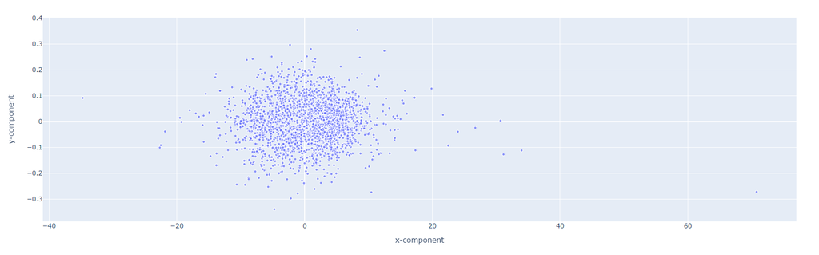

Some interesting patterns: At the farthest left in our model, we see words such as Trump’s, Obama’s, and Hilary. It’s quite self-explanatory why these go together. In the region [-5, -3] x [-0.15, 0], we see multiple places, like Australia, Germanys, and Kenya, next to this rectangle, we see other tangential words like Australian, and kremlin. Overall, the model seems to classify things based off a clear pattern. It’s still kind of hard to see how it makes these decision, but you can get a good idea of it by visualizing the embeddings.